# Multilevel Models and Missing Data Models for Crowdsourced Bicycle Route Ratings

Will Jones

# About This Research

- This work is from my undergraduate thesis at Reed College
- Was advised by Andrew Bray

# Ride Report and the Stress Map

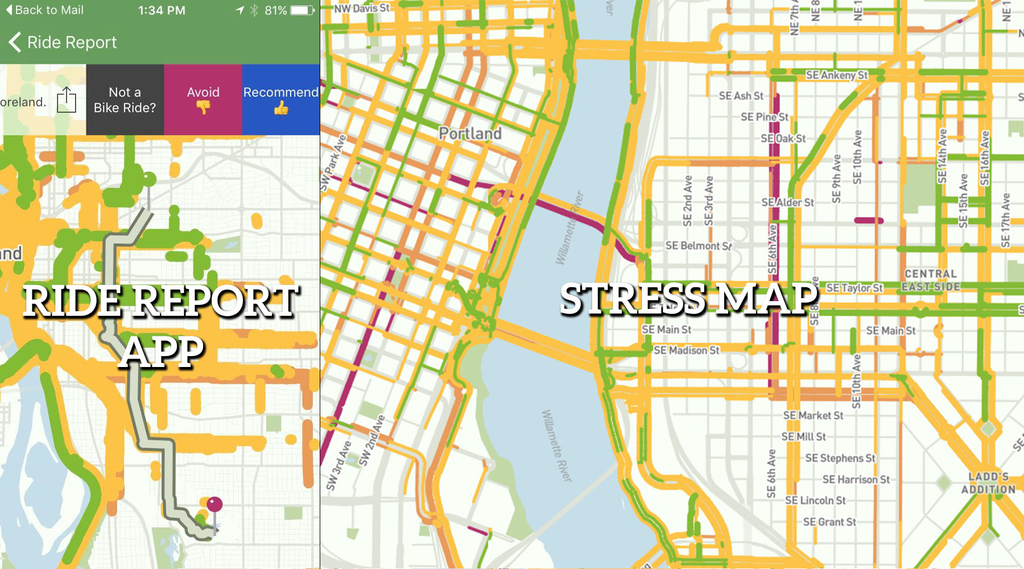

# Three Main Challenges

1. **Develop model for data collection process**
2. Adapt algorithm for map matching
3. Develop model for routes

# Modeling Goals

### Correct for:

- riders’ differing rating criteria
- ride length
- time of day (for traffic and maybe other things)
- weather:
  - Daily: avg. temp, mean wind speed, max gust speed
  - Hourly: rainfall during ride, rainfall past 4 hours

### How to model?

- weather + ride length with linear predictors
- riders with random intercepts
- time of day effect with cyclic splines (by weekday/weekend)

# A Logistic Regression Model

- $y_i$ are ratings
- $X$ are ride predictors
- $j[i]$ is the rider of the $i$th ride
- $t_i$ is the start time of ride $i$ in hours
- $w_i$ is an indicator for weekend

$$y_i \sim \text{Bernoulli}(p_i),$$
$$\text{logit}(p_i) = \alpha_{j[i]} + \beta \cdot X_i + s_{w_i}(t_i)$$

- $s_{w_i}(t)$ are two cyclic cubic splines, for weekdays and weekends, w/ knots at every 3 hours.
- Model fit with gamm4 package in R

# Linear predictors

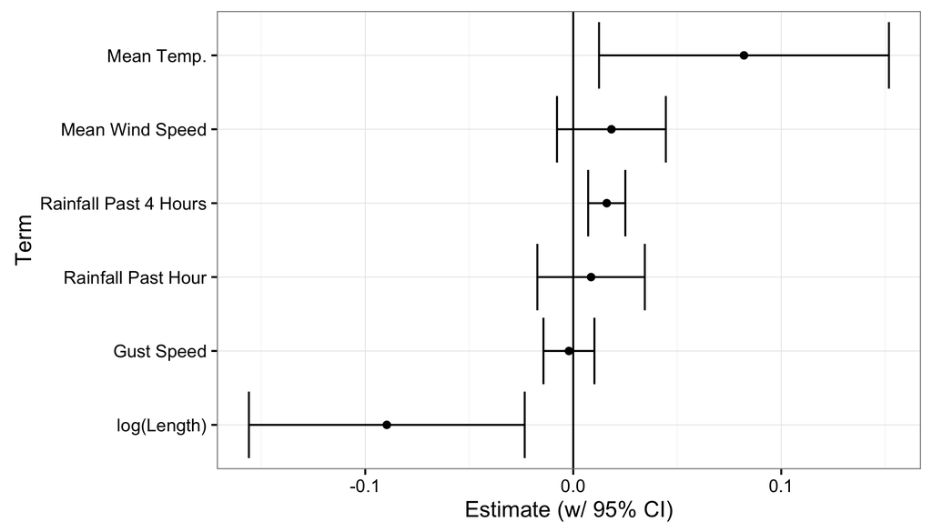

# Bike Lanes Flood!

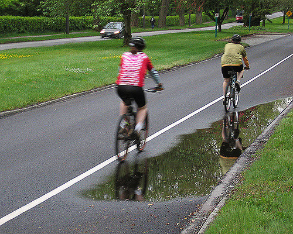

Photo by Richard Drdul. (https://www.flickr.com/photos/drdul/177247505)

# Random Intercepts for Riders

The random intercepts were very informative for the model:

| $\alpha_{j[i]}$ | $\beta X_i$ | $s_{w_i} (t_i)$ | AIC |
| --- | --- | --- | --- |
| X | X | X | 9096 |
|  | X | X | 10755 |
| X |  | X | 9127 |
| X | X |  | 9153 |

- Maybe: Effect of cyclists’ typical route absorbed by intercept

# Cyclic Splines for Time of Day

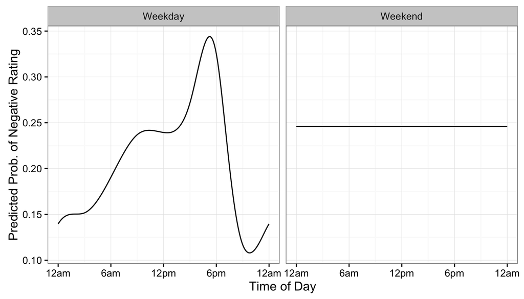

# Time of Day and Riders

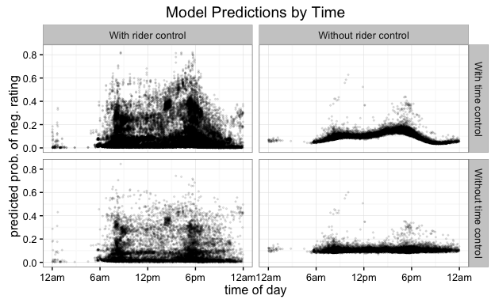

# Conclusion

- This is a start towards a goal of building a better “Stress Map”"

Future models should:

- Make use of the rider intercepts, time of day splines, and weather data
- Use more granular weather data
- Be aware of the correlation between rider intercepts, time of day, and route